# Solución examen

J. Santibáñez

19 de octubre de 2019

## Sección A

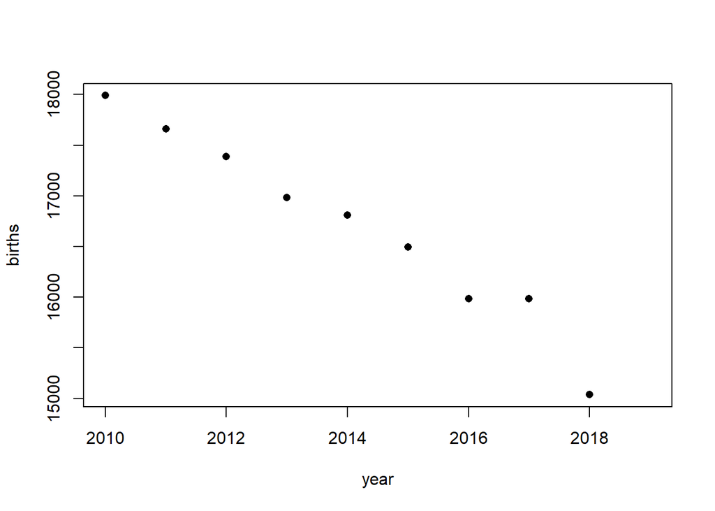

[output not shown]

[output cut: 226 more lines]

```r
year <- 2010:2018
births <- c(17989,17662,17386,16983,16808,16494,15987,15986,15039)
modelo1 <- lm(births ~ year)
modelo2 <- lm(births ~ year + I(year^2))
births2019 <- predict(modelo2, data.frame(year = 2019), interval = 'prediction')
plot(year, births, xlim = c(2010,2019), pch = 16)
```

## Sección B

### Procesamiento de los datos

1. La base contiene 62,530,715 registros.
2. Hay 42 diferentes categorias de productos.
3. Hay 706 cadenas comerciales diferentes.
4. La base presenta varias errores e inconsistencias. Estas observaciones se hacen ex-post, una vez que se hicieron todos los análisis de esta sección: los nombres de las entidades y de los municipios tienen errores, la información de productos, presentación, marca no es consiste, además hay varios valores faltantes.
5. A continuación se presentan los 10 productos más monitoreados en cada entidad.

| X | estado | producto | n | r |
| --- | --- | --- | --- | --- |
| 1 | AGUASCALIENTES | FUD | 12005 | 1 |
| 2 | AGUASCALIENTES | DETERGENTE P/ROPA | 10188 | 2 |
| 3 | AGUASCALIENTES | LECHE ULTRAPASTEURIZADA | 9824 | 3 |
| 4 | AGUASCALIENTES | SHAMPOO | 9654 | 4 |
| 5 | AGUASCALIENTES | REFRESCO | 9481 | 5 |
| 6 | AGUASCALIENTES | DESODORANTE | 8859 | 6 |
| 7 | AGUASCALIENTES | JABON DE TOCADOR | 8517 | 7 |
| 8 | AGUASCALIENTES | CHILES EN LATA | 7946 | 8 |
| 9 | AGUASCALIENTES | YOGHURT | 7401 | 9 |
| 10 | AGUASCALIENTES | MAYONESA | 7173 | 10 |
| 11 | BAJA CALIFORNIA | REFRESCO | 37243 | 1 |
| 12 | BAJA CALIFORNIA | DETERGENTE P/ROPA | 23395 | 2 |
| 13 | BAJA CALIFORNIA | FUD | 19967 | 3 |
| 14 | BAJA CALIFORNIA | SHAMPOO | 19123 | 4 |
| 15 | BAJA CALIFORNIA | JABON DE TOCADOR | 18348 | 5 |
| 16 | BAJA CALIFORNIA | CHILES EN LATA | 16676 | 6 |
| 17 | BAJA CALIFORNIA | GALLETAS | 15873 | 7 |
| 18 | BAJA CALIFORNIA | PANTALLAS | 15703 | 8 |
| 19 | BAJA CALIFORNIA | CEREALES | 15398 | 9 |
| 20 | BAJA CALIFORNIA | DESODORANTE | 14748 | 10 |
| 21 | BAJA CALIFORNIA SUR | REFRESCO | 27770 | 1 |
| 22 | BAJA CALIFORNIA SUR | FUD | 17776 | 2 |
| 23 | BAJA CALIFORNIA SUR | PANTALLAS | 17383 | 3 |
| 24 | BAJA CALIFORNIA SUR | DETERGENTE P/ROPA | 15510 | 4 |
| 25 | BAJA CALIFORNIA SUR | LAVADORAS | 13242 | 5 |
| 26 | BAJA CALIFORNIA SUR | SHAMPOO | 12844 | 6 |
| 27 | BAJA CALIFORNIA SUR | JABON DE TOCADOR | 12799 | 7 |
| 28 | BAJA CALIFORNIA SUR | CHILES EN LATA | 11537 | 8 |
| 29 | BAJA CALIFORNIA SUR | PLANCHAS | 11301 | 9 |
| 30 | BAJA CALIFORNIA SUR | COMPONENTES DE AUDIO | 11036 | 10 |

[output cut: 290 more lines]

6. Walmart es la cadena con más variedad de productos monitoreados, con 8,643,133 de productos.

### Análisis exploratorio

1. Para la canasta de productos para hacer comparaciones temporales y geográficas, cosnideré los 10 productos con más registros en el conjunto de datos.

| producto | n |
| --- | --- |
| REFRESCO | 1247981 |
| DETERGENTE P/ROPA | 990122 |
| FUD | 933410 |
| LECHE ULTRAPASTEURIZADA | 886716 |
| SHAMPOO | 745467 |
| JABON DE TOCADOR | 744914 |
| CHILES EN LATA | 724862 |
| MAYONESA | 697586 |
| YOGHURT | 632362 |
| DESODORANTE | 623684 |

2. Para responder a esta pregunta se encontraron dos dificultades: a) la definición de ciudad es ambigua y b) en el conjunto de datos solamente se dispone del estado, municipio y coordenadas de los establecimientos. Para poder dar una respuesta dentro del tiempo permitido para el examen, consideré los municipios. En la siguiente tabla se muestran las 5 ciudades (municipios) más caras y las 5 ciudades menos caras.

| estado | municipio | canasta_m | n |
| --- | --- | --- | --- |
| MICHOACÁN DE OCAMPO | URUAPAN | 30.10264 | 10 |
| BAJA CALIFORNIA SUR | LA PAZ | 29.61952 | 10 |
| TAMAULIPAS | REYNOSA | 29.41841 | 10 |
| VERACRUZ DE IGNACIO DE LA LLAVE | ORIZABA | 29.38371 | 10 |
| BAJA CALIFORNIA | TIJUANA | 29.35464 | 10 |
| TLAXCALA | HUAMANTLA | 24.94188 | 10 |
| JALISCO | LAGOS DE MORENO | 24.85123 | 10 |
| OAXACA | SANTA CRUZ XOXOCOTLAN | 24.49553 | 10 |
| TLAXCALA | ZACATELCO | 24.49189 | 10 |
| TLAXCALA | CHIAUTEMPAN | 24.33874 | 10 |

De disponer más tiempo, podría utilizar información del INEGI acerca de las localidades, para poder dar una mejor aproximación en términos de *ciudades*.

3. Según los resultados anteriores, la ciudad más cara es Uruapan, Michoacán. Sin embargo, no hay información suficiente para explorar patrones anuales. Por ello se decidió utilizar a la segunda ciudad más cara, La Paz, Baja California Sur.

A continuación se muestran las gráficas de las series de precios por trimestre. Como se puede apreciar, existen ciertos patrones estacionales.

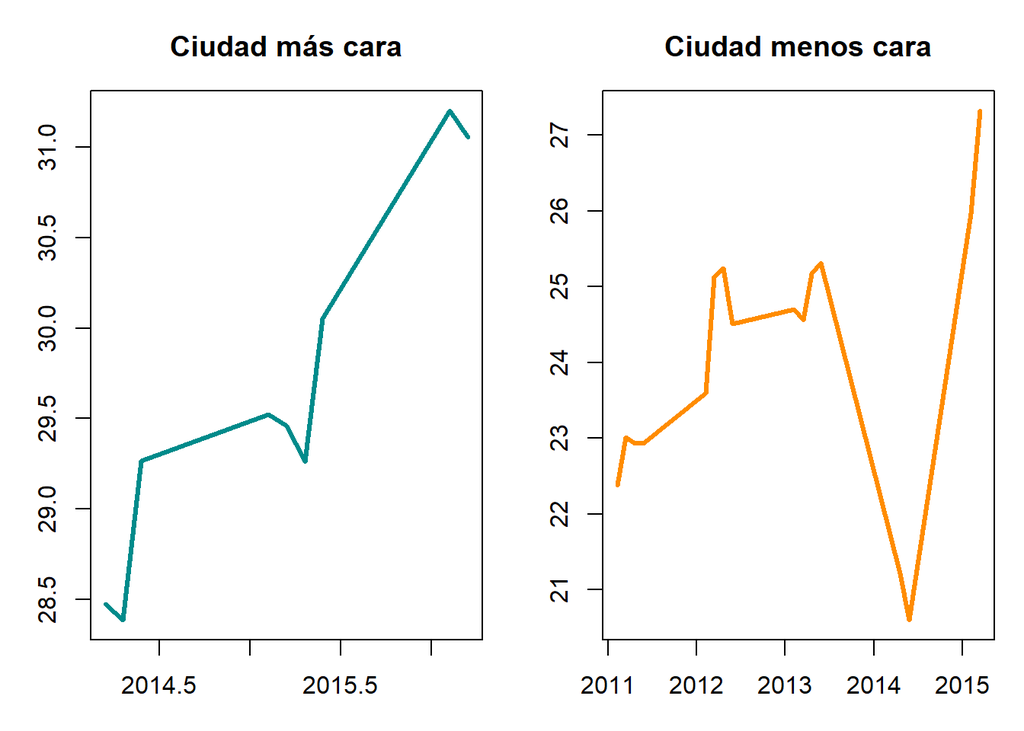

4. Primero se determinó cuál es el estado más caro. Como se puede ver en la tabla siguiente, el estado más caro es Baja California Sur.

| X | estado | canasta_m |
| --- | --- | --- |
| 1 | BAJA CALIFORNIA SUR | 29.36224 |
| 2 | TAMAULIPAS | 29.14200 |
| 3 | NAYARIT | 29.13111 |
| 4 | SAN LUIS POTOSÍ | 29.06201 |
| 5 | BAJA CALIFORNIA | 28.90053 |
| 6 | GUERRERO | 28.89450 |
| 7 | CHIHUAHUA | 28.42621 |
| 8 | MORELOS | 28.41412 |
| 9 | CAMPECHE | 28.39383 |
| 10 | HIDALGO | 28.05907 |
| 11 | COAHUILA DE ZARAGOZA | 28.02058 |
| 12 | QUINTANA ROO | 27.97006 |
| 13 | DURANGO | 27.86916 |
| 14 | SONORA | 27.77516 |
| 15 | CHIAPAS | 27.66926 |
| 16 | AGUASCALIENTES | 27.64331 |
| 17 | VERACRUZ DE IGNACIO DE LA LLAVE | 27.49361 |
| 18 | DISTRITO FEDERAL | 26.93272 |
| 19 | YUCATÁN | 26.78628 |
| 20 | MÉXICO | 26.74418 |
| 21 | PUEBLA | 26.73302 |
| 22 | QUERÉTARO | 26.71886 |
| 23 | COLIMA | 26.65970 |
| 24 | GUANAJUATO | 26.58393 |
| 25 | NUEVO LEÓN | 26.53251 |
| 26 | TABASCO | 26.50267 |
| 27 | ZACATECAS | 26.40220 |
| 28 | OAXACA | 26.24434 |
| 29 | JALISCO | 26.22690 |
| 30 | MICHOACÁN DE OCAMPO | 26.13976 |
| 31 | SINALOA | 25.90553 |
| 32 | TLAXCALA | 25.74807 |

Ahora se hace sólo un análisis de Baja California Sur

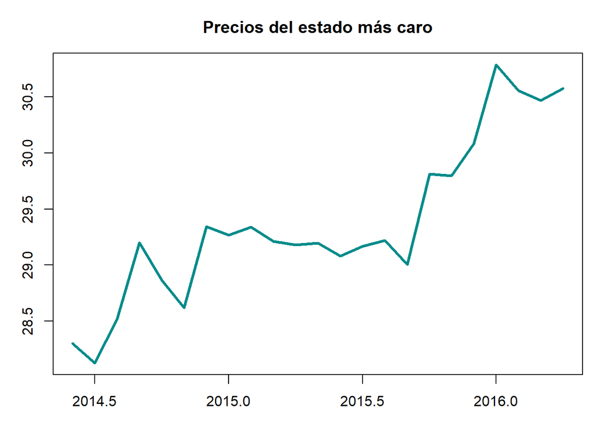

5. El problema de realizar un análisis de series de tiempo es que se debe tener cuidado al momento de organizar la información para formar la serie. En este trabajo, por cuestiones de tiempo, no pude hacer un análisis más detallado, sin embargo, se tiene que homogenerizar los precios de la canasta para considerar productos con las mismas presentaciones o bien, con presentaciones similares, a fin de garantizar comparabilidad de las canastas de productos.

## Sección C

La evidencia señala que las ventas en Estados Unidos disminuyeron en el periodo, -10% en B&M y -11.2 % online, en general, -10.6 %. Sin embargo, la información de Canadá también revela que hubo perdidas, -15.8% de esto se desperenden dos hechos:

- La reducción en las ventas no pudo deberse únicamente a la implementación de BOPS, ya que también hubo perdidas en Canadá.
- La implementación de BOPS ayudó a que las ventas no disminuyeran tanto.
1. Dado que con la información disponible no es posible determinar si la reducción de las ventas en Canadá fue más grave debido a otros factores y no sólo a que no se implementó BOPS, se asumirá que BOPS contribuyó a no tener perdias tan grandes. De ser esto cierto, de haber implementado BOPS en Canadá, se esperaría tener ventas de 27.6207993 millones de dólares, en lugar de 25.853285. Por lo tanto, sí debería extender el programa a Canadá.
2. Suponiendo que en las perdidas en Estados Unidos hubieran tenido la misma magnitud que en Canadá de no ser porque se implemento el programa BOPS, las ventas B&M hubieran sido de 103.3392452 millones de dólares mientras que las ventas online hubieran sido de 129.1800374 millones de dólares , en general, las ventas hubieran sido 232.5192826 millones dólares. De manera que el programa BOPS permitió ganar (o no perter) 14.2452204 millones de dólares.